[figure not shown]

D. Dubois

**Contenu**

1. Présentation et installation de R
2. Présentation de RStudio
3. Structures de données
4. Préparation d’un jeu de données
5. Manipulation d’un jeu de données
6. Analyse d’un jeu de données
7. Visualisation d’un jeu de données

# 1. Présentation de R

- language pour l’analyse de données
- créé en 1996 par Ross Ihaka et Robert Gentleman
- développement assuré par des statisticiens rassemblés dans la **R Development Core Team**
- publié sous licence GNU GPL

**Points forts**

- multiplateforme
- libre et gratuit
- language interprété
- puissant avec possibilité d’extensions car fonctionne avec un système de packages
- création de graphiques avancés, exportables dans différents formats
- grande communauté d’utilisateurs très actifs

**Points faibles**

- plus un language de programmation qu’un logiciel, même si des efforts sont faits pour développer de plus en plus d’interfaces graphiques “presse-bouton”
- pas simple d’accès au départ, même si des efforts sont faits pour simplifier les commandes et instructions
- language limité aux statistiques

**Installation**

- R : https://cran.r-project.org/
- RStudio : https://posit.co/

# 2. RStudio

- Integrated Development Environment (IDE) pour R
- libre, gratuit et multiplateforme

[figure not shown]

**3 zones**

- la console (interpréteur R) et le terminal
- les variables d’environnement et l’historique des commandes
- l’aide et la liste des packages

## La console

- permet d’interagir avec l’interpréteur R
- les flèches haut et bas du clavier permettent de naviguer dans l’historique des commandes
- touche `Entrée` du clavier pour exécuter la commande tapée
- pour stocker une valeur il faut créer une variable
- le signe d’affectation en R est `<-`

```r
x <- 10
```

- on affecte la valeur 10 à la variable x
- on appelle `x` dans la console pour afficher la valeur

```r
x
```

```
## [1] 10
```

- les variables apparaissent dans l’onglet “Environnement”, ce sont les objets en mémoire pour la session en cours
- les commandes entrées dans la console apparaissent dans l’onglet “History”
- les noms de variable peuvent contenir des lettres, chiffres et les symboles “.” et “_”
- ne peuvent pas commencer par un chiffre
- ne pas mettre d’accents
- sensible à la casse (x et X sont deux variables différentes)

## Projet

- permet définir le dossier dans lequel tous les fichiers du projet seront stockés (sources et sorties)
- évite les chemins absolus, utilisation des **chemins relatifs**
- pour créer un nouveau projet : File/New Project
- soit créer un nouveau dossier sur l’ordinateur, soit utiliser un dossier existant

File/New Project

[figure not shown]

## Scripts

- la console ne conserve pas le code une fois la session fermée
- utilisation de scripts, qui permettent de stocker les commandes, et de les réutiliser
- pour créer un script: File/New File/R Script
- c’est un fichier texte, enregistré avec l’extension `*.R`
- pour envoyer le code sélectionné dans la console soit `Run` soit `Ctrl + Entrée`
- `"#"` pour les commentaires

## Notebooks

- plus convivial que le script
- mélange de Markdown (html simplifié) et de code (avec la sortie juste en dessous)
- s’exporte en html ou pdf
- facilite le partage et la lecture du document

File/New File/R Notebook

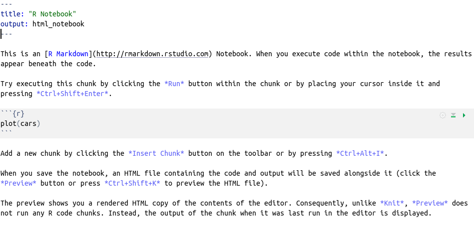

- on peut changer title qui est le titre du notebook
- ne pas toucher à output
- ce qui est après les trois tirets peut être supprimé, c’est un texte d’accueil standard
- un notebook est composé de texte au format markdown et de blocs de codes, appelés chunks
- insert/R pour insérer un nouveau chunk ou `Ctrl + alt + i`
- dans le chunk, `Ctrl + Entrée` pour exécuter la ligne courante et `Ctrl + Maj + Entrée` pour exécuter tout le chunk

le résultat de l’exécution du chunk est affiché juste en dessous

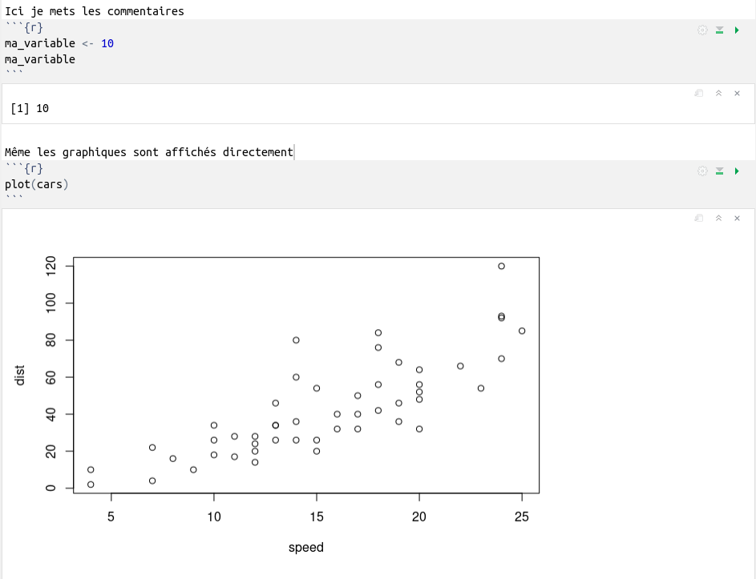

A chaque enregistrement du notebook, R génère le fichier html du notebook

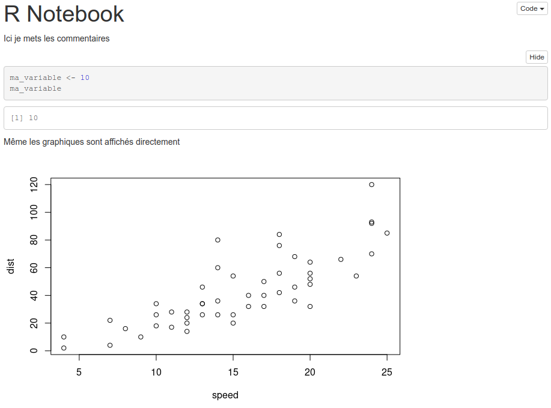

**Markdown**

- html simplifié
- utilisé pour structurer le Notebook avec des titres, du texte en gras ou italique, des liens, des listes à puces ou numérotées etc.
- RStudio propose un guide rapide : Help/Markdown Quick Reference

## Packages

- extensions des fonctionnalités de base (R Core)
- développés et maintenus par la communauté
- regroupés au sein du CRAN (Comprehensive R Archive Network)
- bouton `Install` de l’onglet `Packages`
- taper le nom du package et cliquer sur `Install`
- pour utiliser le package il faut le charger, avec `library(nom_du_package)`
- la commande `library()` est par convention placée dans le premier chunk du notebook (ou en première ligne du script)

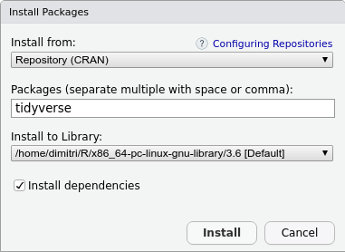

💻 **Pratique**

- créer un nouveau projet
- créer un nouveau notebook
- installer les packages tidyverse et questionr puis les charger

```
install.packages("tidyverse")
install.packages("questionr")
library(tidyverse)
library(questionr)
```

# 3. Structures de données

## Les types de données

- numériques : integer (entier) ou double (décimaux)
- chaînes de caractères : character
- booléens : logical
- catégorielles : factor
- NA : donnée manquante (Not Available)
- typeof(objet) pour connaître le type

```r
a <- "coucou"
print(typeof(a))
```

```
## [1] "character"
```

## Le vecteur

pour stocker plusieurs valeurs dans une variable (tableau unidimensionnel)

```r
tailles <- c(1.75, 1.54, 1.85, 1.92)
tailles
```

```
## [1] 1.75 1.54 1.85 1.92
```

`c()` est une fonction qui concatène les différentes valeurs dans le même vecteur

```r
(poids <- c(72, 59, 110, 95))
```

```
## [1]  72  59 110  95
```

💡 *Dans un chunk, mettre des parenthèses autour du code exécute le code et affiche le résutat*

Un vecteur est un **objet indexé**, c’est à dire que chaque élément a un numéro d’ordre, appelé index, qui permet de le retrouver.  
Pour accéder à un élément du vecteur, utilisation de l’opérateur [] avec dedans l’index de l’élément souhaité  
⚠️ **la numérotation commence à 1**

```r
tailles
```

```
## [1] 1.75 1.54 1.85 1.92
```

```r
tailles[2]
```

```
## [1] 1.54
```

**plusieurs éléments via un vecteur d’index**

```r
tailles[2:3]
```

```
## [1] 1.54 1.85
```

ou

```r
tailles[c(1, 3)]
```

```
## [1] 1.75 1.85
```

Une opération sur un vecteur s’applique à **tous les éléments du vecteur**

```r
(tailles_cm <- tailles * 100)
```

```
## [1] 175 154 185 192
```

```r
(imc <- poids / tailles ^ 2)
```

```
## [1] 23.51020 24.87772 32.14025 25.77040
```

**Autres méthodes pour créer un vecteur**

Avec numeric(), character(), logical() pour des vecteurs vides.  
**Avec un entier en argument cela crée le vecteur avec le nombre d’éléments correspondants**, avec des valeurs par défaut (0 pour numeric, “” pour character et FALSE pour logical)

```r
numeric(10)
```

```
##  [1] 0 0 0 0 0 0 0 0 0 0
```

**Avec l’opérateur ‘`:`’** : crée un vecteur d’entiers qui se suivent

```r
1:10
```

```
##  [1]  1  2  3  4  5  6  7  8  9 10
```

Avec la fonction **`seq`** qui permet de créer une séquence de nombres

```r
seq(from=1, to=10, by=2)
```

```
## [1] 1 3 5 7 9
```

Avec la fonction **`rep`** qui permet de répéter un vecteur

```r
rep(1:3, 2)
```

```
## [1] 1 2 3 1 2 3
```

💡 **Remarques** :

- Les fonctions `seq` et `rep` ont plusieurs arguments possibles, cf. leur documentation.
- Il existe des fonctions pour générer des vecteurs de données aléatoires : `rnorm`, `runif`, `rbinom`, `rpois` etc.

💻 **Pratique**

A partir des données ci-dessous (4 foyers), calculer le revenu global du foyer puis le revenu par personne.

```r
conjoint1 <- c(1200, 1180, 1750, 2100)
conjoint2 <- c(1450, 1870, 1690, 0)
nb_personnes <- c(4, 2, 3, 2)
```

**Fonctions utiles sur un vecteur**

on appelle une fonction avec son nom, suivi de parenthèses avec dedans zéro, un ou plusieurs arguments

- `?nom_fonction` (ou `help("nom_fonction")`) pour afficher l’aide de la fonction
- certaines fonctions ont des arguments obligatoires et des arguments facultatifs
- dans la signature de la fonction les arguments obligatoires n’ont pas de valeur par défaut, les arguments facultatifs en ont un
- par exemple la fonction `mean` a un argument obligatoire et un argument facultatif `na.rm`, qui permet de ne pas considérer les valeurs manquantes (NA) pour calculer la moyenne
- length(v): renvoie la longueur de v (nombre d’éléments)
- mean(v) : renvoie la moyenne de v
- min(v), max(v) : renvoie le minimum (maximum) de v
- sum(v): renvoie la somme des valeurs de v
- range(v): renvoie un vecteur avec le min et le max
- unique(v): renvoie un vecteur à partir de v mais en ayant supprimé toutes les valeurs en double

```r
mean(tailles)
```

```
## [1] 1.765
```

```r
min(tailles)
```

```
## [1] 1.54
```

**Combinaison de vecteurs avec `rbind` et `cbind`**

- `rbind` pour combiner des vecteurs en ligne
- `cbind` pour combiner des vecteurs en colonne

```r
(v1 <- c(1, 2, 3))
```

```
## [1] 1 2 3
```

```r
(v2 <- c(4, 5, 6))
```

```
## [1] 4 5 6
```

**`rbind`**

```r
(rbind(v1, v2))
```

```
##    [,1] [,2] [,3]
## v1    1    2    3
## v2    4    5    6
```

**`cbind`**

```r
(cbind(v1, v2))
```

```
##      v1 v2
## [1,]  1  4
## [2,]  2  5
## [3,]  3  6
```

**Calcul de moyennes sur un objet contenant plusieurs vecteurs : `rowMeans` et `colMeans`**

- `rowMeans` pour calculer la moyenne des lignes
- `colMeans` pour calculer la moyenne des colonnes

```r
(v1 <- seq(1, 10, by=2))
```

```
## [1] 1 3 5 7 9
```

```r
(v2 <- seq(2, 20, by=4))
```

```
## [1]  2  6 10 14 18
```

```r
(mat <- cbind(v1, v2))
```

```
##      v1 v2
## [1,]  1  2
## [2,]  3  6
## [3,]  5 10
## [4,]  7 14
## [5,]  9 18
```

**`rowMeans`**

```r
rowMeans(mat)
```

```
## [1]  1.5  4.5  7.5 10.5 13.5
```

**`colMeans`**

```r
colMeans(mat)
```

```
## v1 v2
##  5 10
```

💡 *Il existe aussi rowSums et colSums pour les sommes*

💻 **Pratique**

1. A partir des deux vecteurs ci-dessous, calculer la témpérature moyenne et le total des précipitations

```r
temperatures <- c(3.4, 4.8, 8.4, 11.4, 15.8, 19.4, 22.2, 21.6, 17.6, 13.4, 7.6, 4.4)
precipitations <- c(47.2, 44.1, 50.4, 74.9, 90.8, 75.6, 63.7, 62, 87.5, 98.6, 81.9, 55.2)
```

2. Avec les vecteurs de notes suivants (6 élèves) :
- faire afficher le min et le max dans chaque matière
- calculer la moyenne générale de chaque élève

```r
python <- c(12, 16, 8, 18, 6, 10)
html <- c(14, 9, 13, 15, 17, 11)
bdd <- c(18, 11, 14, 10, 8, 12)
```

## Le dataframe

- tableau de données bi-dimensionnel (lignes, colonnes)
- chaque colonne est un vecteur de données
- les colonnes peuvent être de type différent

Prenons comme exemple un jeu de données, `hdv2003`, fourni par le package `questionr` chargé précédemment. On charge le jeu de données avec la commande suivante

```r
data("hdv2003")
```

cela a pour effet de mettre le jeu de données dans l’environnement de travail (chargé en mémoire dans la session courante de R)  
*hdv2003* est un extrait de l’enquête *Histoire de vie* réalisée par l’INSEE en 2003. Il contient 2000 individus et 20 variables.

Cliquer sur l’objet dans l’onglet environnement pour voir le tableau de données (on peut aussi appeler la fonction `View(hdv2003)`)

**Fonctions utiles**

- names(df) : affiche le nom des colonnes
- nrow(df) : renvoie le nombre de lignes
- ncol(df) : renvoie le nombre de colonnes
- dim(df) : renvoie un vecteur avec les dimensions, cad nrow et ncol
- names(df) : renvoie les noms des variables (colonnes)
- str(df) : affiche des infos sur le jeu de données - chaque variable avec son type et les premières valeurs (si on clique sur la flèche bleu dans l’environnement cela affiche le contenu de str(df))
- head(df) : affiche les premières lignes
- tail(df) : affiche les dernières lignes

```r
dim(hdv2003)
```

```
## [1] 2000   20
```

```r
names(hdv2003)
```

```
##  [1] "id"            "age"           "sexe"          "nivetud"
##  [5] "poids"         "occup"         "qualif"        "freres.soeurs"
##  [9] "clso"          "relig"         "trav.imp"      "trav.satisf"
## [13] "hard.rock"     "lecture.bd"    "peche.chasse"  "cuisine"
## [17] "bricol"        "cinema"        "sport"         "heures.tv"
```

💻 **Pratique**

- Charger le jeu de données `hdv2003` du package `questionr`
- Appeler chacune des fonctions de “découverte” sur le jeu de données `hdv2003`.

## La matrice

- tableau de données bi-dimensionnel (lignes, colonnes)
- chaque élément est de même type
- utilisée pour les calculs matriciels (calculs mathématiques et opérations algébriques)

**Création**

- `matrix(data, nrow, ncol, byrow=FALSE, dimnames=NULL)`
- `diag(n)` : matrice diagonale de taille n
- `diag(v)` : matrice diagonale avec les éléments de v sur la diagonale

```r
# matrice 3x3 avec des nombres de 1 à 9
(matrice <- matrix(1:9, nrow = 3, ncol = 3, byrow = TRUE))
```

```
##      [,1] [,2] [,3]
## [1,]    1    2    3
## [2,]    4    5    6
## [3,]    7    8    9
```

**Opérations matricielles**

- `%*%` : produit matriciel
- `t(mat)` : transposée de la matrice
- `solve(mat)` : inverse de la matrice
- `det(mat)` : déterminant de la matrice

## La liste

Structure de données qui peut contenir des éléments de types différents (vecteur, matrice, dataframe, autre liste, fonction)

**Création**

`list()`

```r
(liste <- list(nom="Dupont", prenom="Jean", age=45, taille=1.75))
```

```
## $nom
## [1] "Dupont"
##
## $prenom
## [1] "Jean"
##
## $age
## [1] 45
##
## $taille
## [1] 1.75
```

```r
(ma_liste <- list(
  nombre = 42,
  texte = "Bonjour",
  vecteur = c(1, 2, 3),
  matrice = matrix(1:4, nrow = 2),
  logique = TRUE
))
```

```
## $nombre
## [1] 42
##
## $texte
## [1] "Bonjour"
##
## $vecteur
## [1] 1 2 3
##
## $matrice
##      [,1] [,2]
## [1,]    1    3
## [2,]    2    4
##
## $logique
## [1] TRUE
```

# 4. Préparation d’un jeu de données

- la première étape de traitement d’un jeu de données comprend le nettoyage, le recodage et la création de nouvelles variables si besoin
- c’est l’activité qui prend le plus de temps lorsque l’on découvre un jeu de données

**Utilisation des libraires du `tidyverse`**

Ensemble de librairies créées pour faciliter le chargement, le nettoyage, le tri, l’analyse de données et les représentations graphiques  
`library(tidyverse)`

[figure not shown]

ggplot2 (visualisation), dplyr (manipulation des données), tidyr (mise en forme des données), purrr (programmation), readr (importation de données), tibble (tableaux de données), forcats (variables qualitatives), stringr (chaînes de caractères)

## Le Tibble

**Le `tibble` est la version moderne du dataframe**

- par rapport au dataframe, le tibble
  - n’a pas de nom de lignes
  - autorise des noms de colonnes avec espaces, caractères spéciaux, nombres etc.
  - a un affichage par défaut sur qq lignes uniquement, avec des informations sur chaque variable
  - affiche un avertissement si on essaie d’accéder à une colonne qui n’existe pas
- les fonctions des librairies du tidyverse acceptent un dataframe en entrée, mais retournent un tibble

```r
as_tibble(hdv2003)
```

```
## # A tibble: 2,000 × 20
##       id   age sexe  nivetud        poids occup qualif freres.soeurs clso  relig
##    <int> <int> <fct> <fct>          <dbl> <fct> <fct>          <int> <fct> <fct>
##  1     1    28 Femme Enseignement…  2634. Exer… Emplo…             8 Oui   Ni c…
##  2     2    23 Femme <NA>           9738. Etud… <NA>               2 Oui   Ni c…
##  3     3    59 Homme Derniere ann…  3994. Exer… Techn…             2 Non   Ni c…
##  4     4    34 Homme Enseignement…  5732. Exer… Techn…             1 Non   Appa…
##  5     5    71 Femme Derniere ann…  4329. Retr… Emplo…             0 Oui   Prat…
##  6     6    35 Femme Enseignement…  8675. Exer… Emplo…             5 Non   Ni c…
##  7     7    60 Femme Derniere ann…  6166. Au f… Ouvri…             1 Oui   Appa…
##  8     8    47 Homme Enseignement… 12892. Exer… Ouvri…             5 Non   Ni c…
##  9     9    20 Femme <NA>           7809. Etud… <NA>               4 Oui   Appa…
## 10    10    28 Homme Enseignement…  2277. Exer… Autre              2 Non   Prat…
## # ℹ 1,990 more rows
## # ℹ 10 more variables: trav.imp <fct>, trav.satisf <fct>, hard.rock <fct>,
## #   lecture.bd <fct>, peche.chasse <fct>, cuisine <fct>, bricol <fct>,
## #   cinema <fct>, sport <fct>, heures.tv <dbl>
```

un tibble peut également être converti en dataframe avec la fonction as.data.frame()

## Lecture d’un jeu de données

- le csv est le format “standard” pour le stockage et le partage de données
- c’est un fichier texte avec un séparateur de colonnes (le point-virgule, la virgule ou la tabulation)
- deux fonctions pour ouvrir un fichier csv:
  - read_csv : fichiers avec une virgule comme séparateur et le point en décimale
  - read_csv2 : fichiers avec le point-virgule comme séparateur et la virgule en décimale (comme en France par exemple)

💡 *RStudio propose une interface graphique pour l’import de données, en cliquant sur le bouton “Import Dataset” dans l’onglet Environment*

## Ecriture d’un jeu de données

Pour écrire dans un fichier csv, il y a les fonctions write_csv et write_csv2

**Sérialisation**

- pour sauvegarder des objets R au format R
- permet de sauvegarder plusieurs objets R dans un seul fichier (extension `*.Rdata`)
- fonction `save(objets, file="fichier.Rdata")`.
- fonction `load("fichier.Rdata")` pour recharger les objets dans l’environnement de la session R

## Recodage des variables catégorielles

### Renommer les modalités

Fonction `fct_recode` (qui vient du package forcats)

```r
freq(hdv2003$qualif)
```

```
##                            n    % val%
## Ouvrier specialise       203 10.2 12.3
## Ouvrier qualifie         292 14.6 17.7
## Technicien                86  4.3  5.2
## Profession intermediaire 160  8.0  9.7
## Cadre                    260 13.0 15.7
## Employe                  594 29.7 35.9
## Autre                     58  2.9  3.5
## NA                       347 17.3   NA
```

💡 *la fonction `freq`, du package `questionr` fournit des informations sur une variable catégorielle : effectifs, pourcentages (avec et sans NA)*  
*`?questionr::freq` pour afficher l’aide*

💡 *Les modalités d’une variable catégorielle sont appelé des `levels`*

```r
levels(hdv2003$qualif)
```

```
## [1] "Ouvrier specialise"       "Ouvrier qualifie"
## [3] "Technicien"               "Profession intermediaire"
## [5] "Cadre"                    "Employe"
## [7] "Autre"
```

`fct_recode(vecteur, nouveau nom = ancien nom, ...)`

```r
hdv2003$qualif_grouped <- fct_recode(
  hdv2003$qualif,
  "Ouvrier" = "Ouvrier specialise",
  "Ouvrier" = "Ouvrier qualifie",
  "Interm" = "Technicien",
  "Interm" = "Profession intermediaire"
)
freq(hdv2003$qualif_grouped)
```

```
##           n    % val%
## Ouvrier 495 24.8 29.9
## Interm  246 12.3 14.9
## Cadre   260 13.0 15.7
## Employe 594 29.7 35.9
## Autre    58  2.9  3.5
## NA      347 17.3   NA
```

💡 le “$” permet d’afficher un vecteur d’un dataframe, mais permet aussi d’en créer un nouveau, autrement dit de créer une nouvelle variable dans le dataframe.

Pour recoder une modalité en variable manquante utilisation de `NULL` comme nouveau nom

```r
hdv2003$qualif_grouped <- fct_recode(hdv2003$qualif_grouped, NULL="Autre")
freq(hdv2003$qualif_grouped)
```

```
##           n    % val%
## Ouvrier 495 24.8 31.0
## Interm  246 12.3 15.4
## Cadre   260 13.0 16.3
## Employe 594 29.7 37.2
## NA      405 20.2   NA
```

```r
levels(hdv2003$qualif_grouped)
```

```
## [1] "Ouvrier" "Interm"  "Cadre"   "Employe"
```

Pour coder les `NA` en modalité, fonction `fct_na_value_to_level`

```r
hdv2003$qualif_grouped <- fct_na_value_to_level(hdv2003$qualif_grouped)
levels(hdv2003$qualif_grouped)
```

```
## [1] "Ouvrier" "Interm"  "Cadre"   "Employe" NA
```

une autre façon pour regrouper les modalités est d’utiliser **`fct_collapse`**

```r
hdv2003$qualif_rec <- fct_collapse(
  hdv2003$qualif,
  "Ouvrier"=c("Ouvrier specialise", "Ouvrier qualifie"),
  "Interm"=c("Technicien", "Profession intermediaire"))
freq(hdv2003$qualif_rec)
```

```
##           n    % val%
## Ouvrier 495 24.8 29.9
## Interm  246 12.3 14.9
## Cadre   260 13.0 15.7
## Employe 594 29.7 35.9
## Autre    58  2.9  3.5
## NA      347 17.3   NA
```

💡 *Remarques* :

1. `fct_other()` pour regrouper un ensemble de modalités dans la catégorie “Other”
2. `fct_lump()` pour regrouper les modalités les moins fréquentes dans la catégorie “Other”
3. interface graphique, proposée par `questionr`, à partir de **`Addins`** puis **`Levels Recoding`**.

### Réordonner les modalités

**`fct_relevel`**

```r
hdv2003$qualif_rec <- fct_relevel(
    hdv2003$qualif,
    "Cadre", "Profession intermediaire", "Technicien",
    "Employe", "Ouvrier qualifie", "Ouvrier specialise",
    "Autre"
)
freq(hdv2003$qualif_rec)
```

```
##                            n    % val%
## Cadre                    260 13.0 15.7
## Profession intermediaire 160  8.0  9.7
## Technicien                86  4.3  5.2
## Employe                  594 29.7 35.9
## Ouvrier qualifie         292 14.6 17.7
## Ouvrier specialise       203 10.2 12.3
## Autre                     58  2.9  3.5
## NA                       347 17.3   NA
```

💻 **Pratique**

1. dans les données hdv2003, recoder la variable `relig` afin d’obtenir

```
                              n    % val%
Pratiquant                  708 35.4 35.4
Appartenance                760 38.0 38.0
Ni croyance ni appartenance 399 20.0 20.0
Rejet                        93  4.7  4.7
NSP                          40  2.0  2.0
```

2. recoder la variable `nivetud` afin d’obtenir

```
                                          n    % val%
N'a jamais fait d'etudes                 39  2.0  2.1
Études primaires                        427 21.3 22.6
1er cycle                               204 10.2 10.8
2eme cycle                              183  9.2  9.7
Enseignement technique ou professionnel 594 29.7 31.5
Enseignement superieur                  441 22.0 23.4
NA                                      112  5.6   NA
```

3. ré-ordonner les modalités de cette variable afin d’obtenir

```
                                         n    % val%
Enseignement superieur                  441 22.0 23.4
Enseignement technique ou professionnel 594 29.7 31.5
2eme cycle                              183  9.2  9.7
1er cycle                               204 10.2 10.8
Études primaires                        427 21.3 22.6
N'a jamais fait d'etudes                 39  2.0  2.1
NA                                      112  5.6   NA
```

## Création d’une variable catégorielle

*à partir d’une variable numérique*

**`cut()`**

- création de classes à partir d’une variable numérique
- exemple : une variable de revenu
- l’argument `breaks` va permettre de définir les intervalles des classes

`breaks=nombre` : l’interpréteur va créer `nombre` classes de même largeur

```r
hdv2003$age_classe <- cut(hdv2003$age, breaks=5)
freq(hdv2003$age_classe)
```

```
##               n    % val%
## (17.9,33.8] 454 22.7 22.7
## (33.8,49.6] 628 31.4 31.4
## (49.6,65.4] 556 27.8 27.8
## (65.4,81.2] 319 16.0 16.0
## (81.2,97.1]  43  2.1  2.1
```

`breaks=vecteur` : l’interpréteur va créer des classes en fonction des valeurs du vecteur

```r
hdv2003$age_classe2 <- cut(
    hdv2003$age,
    breaks = c(18, 25, 35, 45, 55, 65, 100),
    include.lowest = T  # pour inclure le 18
)
freq(hdv2003$age_classe2)
```

```
##            n    % val%
## [18,25]  191  9.6  9.6
## (25,35]  338 16.9 16.9
## (35,45]  390 19.5 19.5
## (45,55]  414 20.7 20.7
## (55,65]  305 15.2 15.2
## (65,100] 362 18.1 18.1
```

💡 le package *questionr* propose une interface graphique : Addins/Numeric range dividing

**`if_else`**

Créer une variable catégorielle à deux modalités en fonction des valeurs d’une variable numérique

`if_else(test, valeur si vrai, valeur si faux)`

```r
(v <- c(12, 14, 8, 16, 4))
```

```
## [1] 12 14  8 16  4
```

```r
if_else(v > 10, "Supérieur à 10", "Inférieur à 10")
```

```
## [1] "Supérieur à 10" "Supérieur à 10" "Inférieur à 10" "Supérieur à 10"
## [5] "Inférieur à 10"
```

`case_when` : étend `if_else` à plusieurs conditions, sous la forme `condition ~ valeur`  
⚠️ les tests sont effectués dans l’ordre, donc il faut aller du plus spécifique au plus large

```r
hdv2003$statut <- case_when(
    hdv2003$age > 60 & hdv2003$sexe == "Homme" ~ "Homme de plus de 60 ans",
    hdv2003$age > 60 & hdv2003$sexe == "Femme" ~ "Femme de plus de 60 ans",
    TRUE ~ "Autre"
)

freq(hdv2003$statut)
```

```
##                            n    % val%
## Autre                   1512 75.6 75.6
## Femme de plus de 60 ans  266 13.3 13.3
## Homme de plus de 60 ans  222 11.1 11.1
```

Comme TRUE est toujours vrai toutes les autres combinaisons sont codées “Autre”.

💻 **Pratique**

1. découper la variable heures.tv en classes afin d’obtenir le tableau de fréquences suivant

```
       n   %    val%
[0,1]  684 34.2 34.3
(1,2]  535 26.8 26.8
(2,4]  594 29.7 29.8
(4,6]  138  6.9  6.9
(6,12]  44  2.2  2.2
NA       5  0.2   NA
```

2. avec `if_else`, créer la variable `cinema_bd` qui groupe les personnes qui vont au cinéma et qui lisent des bd. Les autres sont mis dans “Autre”. Le résultat attendu est

```
               n    % val%
Autre        1971 98.6 98.6
Cinéma et BD   29  1.5  1.5
```

3. avec `case_when` créer la variable `genre_fratrie` ayant les modalités : Homme avec plus de 2 frères et soeurs, Femme avec plus de 2 frères et soeurs, Autre. Le résulat attendu est

```
                                         n    % val%
Autre                                  1001 50.0 50.0
Femme avec plus de 2 frères et soeurs  546  27.3 27.3
Homme avec plus de 2 frères et soeurs  453  22.7 22.7
```

## Mise en forme des données

Pour pouvoir manipuler les données il faut qu’elles soient bien rangées, ie “**tidy**”, notamment:

- chaque variable est dans une colonne unique
- chaque colonne contient une unique variable
- chaque ligne correspond à une observation pour chaque variable
- les cellules du tableau représentent les valeurs de chaque observation pour chaque variable

Exemple de données non tidy : Population de 3 pays sur 4 années

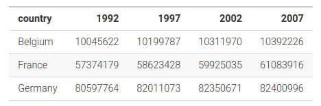

pour que ce soit tidy il faudrait

- une observation par ligne
- une variable année et une variable population

Le dataset serait alors

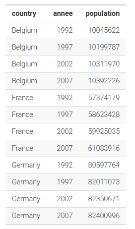

Fonction `pivot_longer` pour créer un dataset “plus long” c’est à dire avec plus de lignes

```
##   country     2002     2007
## 1 Belgium 10311970 10392226
## 2  France 59925035 61083916
## 3 Germany 82350671 82400996
```

les colonnes 2002 et 2007 devraient être dans une colonne “année” et les valeurs dans une colonne “population”

```r
pivot_longer(data=tidy_ex, cols=c("2002", "2007"), names_to="annee", values_to="population")
```

```
## # A tibble: 6 × 3
##   country annee population
##   <chr>   <chr>      <dbl>
## 1 Belgium 2002    10311970
## 2 Belgium 2007    10392226
## 3 France  2002    59925035
## 4 France  2007    61083916
## 5 Germany 2002    82350671
## 6 Germany 2007    82400996
```

Fonction `pivot_wider` pour à l’inverse créer un dataset “plus large”, c’est à dire avec plus de colonnes

```
##   country continent year variable        value
## 1 Belgium    Europe 2002  lifeExp       78.320
## 2 Belgium    Europe 2002      pop 10311970.000
## 3 Belgium    Europe 2007  lifeExp       79.441
## 4 Belgium    Europe 2007      pop 10392226.000
## 5  France    Europe 2002  lifeExp       79.590
## 6  France    Europe 2002      pop 59925035.000
## 7  France    Europe 2007  lifeExp       80.657
## 8  France    Europe 2007      pop 61083916.000
```

la colonne variable devrait être divisée en deux variables lifeExp et pop

```r
pivot_wider(data=tidy_ex1, names_from=variable, values_from=value)
```

```
## # A tibble: 4 × 5
##   country continent  year lifeExp      pop
##   <chr>   <chr>     <dbl>   <dbl>    <dbl>
## 1 Belgium Europe     2002    78.3 10311970
## 2 Belgium Europe     2007    79.4 10392226
## 3 France  Europe     2002    79.6 59925035
## 4 France  Europe     2007    80.7 61083916
```

# 5. Manipulation d’un jeu de données

le package `dplyr` du `tidyverse` propose 6 fonctions : `slice, filter, select, rename, arrange et mutate`

Pour les exemples, utilisation des datasets du package `nycflights23` (données des vols de départ de 3 aéroports de New-York en 2023)

```
install.packages("nycflights23")
library(nycflights23)
```

```r
data("flights")
data("airports")
data("airlines")
```

### slice

Permet de sélectionner des lignes du dataset par leur index

```r
slice(airports, 2:8)
```

```
## # A tibble: 7 × 8
##   faa   name                                  lat    lon   alt    tz dst   tzone
##   <chr> <chr>                               <dbl>  <dbl> <dbl> <dbl> <chr> <chr>
## 1 AAP   Andrau Airpark                       29.7  -95.6    79    -6 A     Amer…
## 2 ABE   Lehigh Valley International Airport  40.7  -75.4   393    -5 A     Amer…
## 3 ABI   Abilene Regional Airport             32.4  -99.7  1791    -6 A     Amer…
## 4 ABL   Ambler Airport                       67.1 -158.    334    -9 A     Amer…
## 5 ABQ   Albuquerque International Sunport    35.0 -107.   5355    -7 A     Amer…
## 6 ABR   Aberdeen Regional Airport            45.4  -98.4  1302    -6 A     Amer…
## 7 ABY   Southwest Georgia Regional Airport   31.5  -84.2   197    -5 A     Amer…
```

### filter

Permet de sélectionner des lignes du dataset en fonction de critères

Tous les vols du mois de janvier

```r
filter(flights, month==1)
```

```
## # A tibble: 36,020 × 19
##     year month   day dep_time sched_dep_time dep_delay arr_time sched_arr_time
##    <int> <int> <int>    <int>          <int>     <dbl>    <int>          <int>
##  1  2023     1     1        1           2038       203      328              3
##  2  2023     1     1       18           2300        78      228            135
##  3  2023     1     1       31           2344        47      500            426
##  4  2023     1     1       33           2140       173      238           2352
##  5  2023     1     1       36           2048       228      223           2252
##  6  2023     1     1      503            500         3      808            815
##  7  2023     1     1      520            510        10      948            949
##  8  2023     1     1      524            530        -6      645            710
##  9  2023     1     1      537            520        17      926            818
## 10  2023     1     1      547            545         2      845            852
## # ℹ 36,010 more rows
## # ℹ 11 more variables: arr_delay <dbl>, carrier <chr>, flight <int>,
## #   tailnum <chr>, origin <chr>, dest <chr>, air_time <dbl>, distance <dbl>,
## #   hour <dbl>, minute <dbl>, time_hour <dttm>
```

**Plusieurs conditions**

Tous les vols qui ont entre 10 et 15 minutes de retard au décollage

```r
filter(flights, dep_delay >= 10, dep_delay <= 15)
```

```
## # A tibble: 17,829 × 19
##     year month   day dep_time sched_dep_time dep_delay arr_time sched_arr_time
##    <int> <int> <int>    <int>          <int>     <dbl>    <int>          <int>
##  1  2023     1     1      520            510        10      948            949
##  2  2023     1     1      613            600        13      834            836
##  3  2023     1     1      810            800        10     1153           1147
##  4  2023     1     1      811            800        11     1122           1136
##  5  2023     1     1      814            800        14     1048           1058
##  6  2023     1     1      833            820        13     1436           1435
##  7  2023     1     1      840            828        12     1136           1140
##  8  2023     1     1      858            845        13     1042           1045
##  9  2023     1     1      859            844        15     1207           1209
## 10  2023     1     1     1005            950        15     1226           1235
## # ℹ 17,819 more rows
## # ℹ 11 more variables: arr_delay <dbl>, carrier <chr>, flight <int>,
## #   tailnum <chr>, origin <chr>, dest <chr>, air_time <dbl>, distance <dbl>,
## #   hour <dbl>, minute <dbl>, time_hour <dttm>
```

💡 *Remarques* :

1. `dplyr` combine automatiquement avec l’opérateur `&` les conditions séparées par une virgule, donc `filter(flights, dep_delay >= 10, dep_delay <= 15)` est équivalent à `filter(flights, dep_delay >= 10 & dep_delay <= 15)`.
2. pour le `OU` par contre, il faut forcément `filter(flights, dep_delay < 10 | dep_delay > 15)`

```r
filter(flights, month == 1, dep_delay >= 10, dep_delay <= 15)
```

```
## # A tibble: 1,604 × 19
##     year month   day dep_time sched_dep_time dep_delay arr_time sched_arr_time
##    <int> <int> <int>    <int>          <int>     <dbl>    <int>          <int>
##  1  2023     1     1      520            510        10      948            949
##  2  2023     1     1      613            600        13      834            836
##  3  2023     1     1      810            800        10     1153           1147
##  4  2023     1     1      811            800        11     1122           1136
##  5  2023     1     1      814            800        14     1048           1058
##  6  2023     1     1      833            820        13     1436           1435
##  7  2023     1     1      840            828        12     1136           1140
##  8  2023     1     1      858            845        13     1042           1045
##  9  2023     1     1      859            844        15     1207           1209
## 10  2023     1     1     1005            950        15     1226           1235
## # ℹ 1,594 more rows
## # ℹ 11 more variables: arr_delay <dbl>, carrier <chr>, flight <int>,
## #   tailnum <chr>, origin <chr>, dest <chr>, air_time <dbl>, distance <dbl>,
## #   hour <dbl>, minute <dbl>, time_hour <dttm>
```

**Possible de passer le résultat d’une fonction dans la condition**

Les vols avec la distance la plus longue

```r
filter(flights, distance == max(distance))
```

```
## # A tibble: 667 × 19
##     year month   day dep_time sched_dep_time dep_delay arr_time sched_arr_time
##    <int> <int> <int>    <int>          <int>     <dbl>    <int>          <int>
##  1  2023     1     1      949            900        49       NA           1525
##  2  2023     1     1     1023           1000        23     1637           1610
##  3  2023     1     2      919            900        19     1543           1525
##  4  2023     1     2      951           1000        -9     1620           1610
##  5  2023     1     3      922            900        22     1535           1525
##  6  2023     1     3     1007           1000         7     1630           1610
##  7  2023     1     4      912            900        12     1511           1525
##  8  2023     1     4     1001           1000         1     1630           1610
##  9  2023     1     5      854            900        -6     1454           1525
## 10  2023     1     5      949           1000       -11     1600           1610
## # ℹ 657 more rows
## # ℹ 11 more variables: arr_delay <dbl>, carrier <chr>, flight <int>,
## #   tailnum <chr>, origin <chr>, dest <chr>, air_time <dbl>, distance <dbl>,
## #   hour <dbl>, minute <dbl>, time_hour <dttm>
```

### select

Permet de sélectionner les colonnes du dataset  
Sélection des colonnes latitude et longitude

```r
select(airports, lat, lon)
```

```
## # A tibble: 1,251 × 2
##      lat    lon
##    <dbl>  <dbl>
##  1  29.7  -85.0
##  2  29.7  -95.6
##  3  40.7  -75.4
##  4  32.4  -99.7
##  5  67.1 -158.
##  6  35.0 -107.
##  7  45.4  -98.4
##  8  31.5  -84.2
##  9  41.3  -70.1
## 10  31.6  -97.2
## # ℹ 1,241 more rows
```

Un “`-`” devant le nom de colonne affiche toutes les colonnes sauf celle avec le moins

```r
select(airports, -lat)
```

```
## # A tibble: 1,251 × 7
##    faa   name                                   lon   alt    tz dst   tzone
##    <chr> <chr>                                <dbl> <dbl> <dbl> <chr> <chr>
##  1 AAF   Apalachicola Regional Airport        -85.0    20    -5 A     America/N…
##  2 AAP   Andrau Airpark                       -95.6    79    -6 A     America/C…
##  3 ABE   Lehigh Valley International Airport  -75.4   393    -5 A     America/N…
##  4 ABI   Abilene Regional Airport             -99.7  1791    -6 A     America/C…
##  5 ABL   Ambler Airport                      -158.    334    -9 A     America/A…
##  6 ABQ   Albuquerque International Sunport   -107.   5355    -7 A     America/D…
##  7 ABR   Aberdeen Regional Airport            -98.4  1302    -6 A     America/C…
##  8 ABY   Southwest Georgia Regional Airport   -84.2   197    -5 A     America/N…
##  9 ACK   Nantucket Memorial Airport           -70.1    47    -5 A     America/N…
## 10 ACT   Waco Regional Airport                -97.2   516    -6 A     America/C…
## # ℹ 1,241 more rows
```

Possible de renommer les variables pour l’affichage

```r
select(airports, latitude=lat, longitude=lon)
```

```
## # A tibble: 1,251 × 2
##    latitude longitude
##       <dbl>     <dbl>
##  1     29.7     -85.0
##  2     29.7     -95.6
##  3     40.7     -75.4
##  4     32.4     -99.7
##  5     67.1    -158.
##  6     35.0    -107.
##  7     45.4     -98.4
##  8     31.5     -84.2
##  9     41.3     -70.1
## 10     31.6     -97.2
## # ℹ 1,241 more rows
```

`select` peut prendre comme argument des éléments permettant une sélection selon des critères

```r
select(flights, starts_with("dep_"))
```

```
## # A tibble: 435,352 × 2
##    dep_time dep_delay
##       <int>     <dbl>
##  1        1       203
##  2       18        78
##  3       31        47
##  4       33       173
##  5       36       228
##  6      503         3
##  7      520        10
##  8      524        -6
##  9      537        17
## 10      547         2
## # ℹ 435,342 more rows
```

il y a aussi *ends_with*, *contains* et *matches*

## rename

Pour renommer les colonnes  
nouveau nom = ancien nom  
si le nouveau nom (ou l’ancien) comporte un ou des espace(s) il faut mettre entre guillemets

```r
rename(airports, longitude=lon, latitude=lat, altitude=alt)
```

```
## # A tibble: 1,251 × 8
##    faa   name                      latitude longitude altitude    tz dst   tzone
##    <chr> <chr>                        <dbl>     <dbl>    <dbl> <dbl> <chr> <chr>
##  1 AAF   Apalachicola Regional Ai…     29.7     -85.0       20    -5 A     Amer…
##  2 AAP   Andrau Airpark                29.7     -95.6       79    -6 A     Amer…
##  3 ABE   Lehigh Valley Internatio…     40.7     -75.4      393    -5 A     Amer…
##  4 ABI   Abilene Regional Airport      32.4     -99.7     1791    -6 A     Amer…
##  5 ABL   Ambler Airport                67.1    -158.       334    -9 A     Amer…
##  6 ABQ   Albuquerque Internationa…     35.0    -107.      5355    -7 A     Amer…
##  7 ABR   Aberdeen Regional Airport     45.4     -98.4     1302    -6 A     Amer…
##  8 ABY   Southwest Georgia Region…     31.5     -84.2      197    -5 A     Amer…
##  9 ACK   Nantucket Memorial Airpo…     41.3     -70.1       47    -5 A     Amer…
## 10 ACT   Waco Regional Airport         31.6     -97.2      516    -6 A     Amer…
## # ℹ 1,241 more rows
```

## arrange

Pour ordonner le dataset selon les valeurs d’une ou plusieurs colonnes

```r
arrange(flights, dep_delay)
```

```
## # A tibble: 435,352 × 19
##     year month   day dep_time sched_dep_time dep_delay arr_time sched_arr_time
##    <int> <int> <int>    <int>          <int>     <dbl>    <int>          <int>
##  1  2023     8    16     1839           1929       -50     2254           2218
##  2  2023    12     2     2147           2225       -38     2332             35
##  3  2023     9     3     1801           1834       -33     1934           2040
##  4  2023     8    13     1804           1834       -30     1947           2040
##  5  2023     1    28     1930           1959       -29     2308           2336
##  6  2023     1    18     2103           2129       -26     2301           2336
##  7  2023     5     5     1129           1155       -26     1337           1420
##  8  2023     4    16      925            950       -25     1102           1140
##  9  2023    11    14     2055           2120       -25     2215           2239
## 10  2023    12     6     2234           2259       -25     2350             30
## # ℹ 435,342 more rows
## # ℹ 11 more variables: arr_delay <dbl>, carrier <chr>, flight <int>,
## #   tailnum <chr>, origin <chr>, dest <chr>, air_time <dbl>, distance <dbl>,
## #   hour <dbl>, minute <dbl>, time_hour <dttm>
```

Fonction `desc()` pour inverser l’ordre (décroissant)

```r
arrange(flights, desc(dep_delay))
```

```
## # A tibble: 435,352 × 19
##     year month   day dep_time sched_dep_time dep_delay arr_time sched_arr_time
##    <int> <int> <int>    <int>          <int>     <dbl>    <int>          <int>
##  1  2023    12    17     1953           1340      1813     2155           1543
##  2  2023    10     1     1240            659      1781     1407            835
##  3  2023     4    25     1201            659      1742     1315            818
##  4  2023     2     7     2045           1700      1665     2352           2025
##  5  2023     4    20      926            619      1627     1135            822
##  6  2023    10    29      856            600      1616     1050            805
##  7  2023     4    30     1818           1617      1561     2001           1820
##  8  2023     3    17     2027           1830      1557     2346           2139
##  9  2023     3    29      633            525      1508      820            700
## 10  2023     3    19     1154           1201      1433     1321           1335
## # ℹ 435,342 more rows
## # ℹ 11 more variables: arr_delay <dbl>, carrier <chr>, flight <int>,
## #   tailnum <chr>, origin <chr>, dest <chr>, air_time <dbl>, distance <dbl>,
## #   hour <dbl>, minute <dbl>, time_hour <dttm>
```

Plusieurs critères

```r
arrange(flights, month, desc(dep_delay))
```

```
## # A tibble: 435,352 × 19
##     year month   day dep_time sched_dep_time dep_delay arr_time sched_arr_time
##    <int> <int> <int>    <int>          <int>     <dbl>    <int>          <int>
##  1  2023     1     2      842           1241      1201     1323           1730
##  2  2023     1    30     1024           1630      1074     1400           2007
##  3  2023     1    11      723           1400      1043      951           1627
##  4  2023     1    13      850           1600      1010     1059           1807
##  5  2023     1     6     1045           1759      1006     1327           2126
##  6  2023     1    21     1301           2059       962     1416           2229
##  7  2023     1    19     1129           1929       960     1416           2239
##  8  2023     1    29     1105           1929       936     1407           2239
##  9  2023     1    19     1201           2030       931     1526              6
## 10  2023     1    19     1054           1959       895     1347           2311
## # ℹ 435,342 more rows
## # ℹ 11 more variables: arr_delay <dbl>, carrier <chr>, flight <int>,
## #   tailnum <chr>, origin <chr>, dest <chr>, air_time <dbl>, distance <dbl>,
## #   hour <dbl>, minute <dbl>, time_hour <dttm>
```

## mutate

Pour créer de nouvelles variables

```r
head(select(flights, air_time), 5)
```

```
## # A tibble: 5 × 1
##   air_time
##      <dbl>
## 1      367
## 2      108
## 3      190
## 4      108
## 5       80
```

Création d’une variable `air_time_hours`

```r
flights <- mutate(flights, air_time_hours = air_time / 60)
head(select(flights, air_time, air_time_hours), 5)
```

```
## # A tibble: 5 × 2
##   air_time air_time_hours
##      <dbl>          <dbl>
## 1      367           6.12
## 2      108           1.8
## 3      190           3.17
## 4      108           1.8
## 5       80           1.33
```

Plusieurs nouvelles variables d’un coup

```r
flights <- mutate(
    flights,
    distance_km = distance / 0.62137,
    vitesse = distance_km / air_time_hours
)
select(flights, air_time_hours, distance_km, vitesse)
```

```
## # A tibble: 435,352 × 3
##    air_time_hours distance_km vitesse
##             <dbl>       <dbl>   <dbl>
##  1           6.12       4023.    658.
##  2           1.8        1223.    680.
##  3           3.17       2536.    801.
##  4           1.8        1024.    569.
##  5           1.33        785.    589.
##  6           2.57       1746.    680.
##  7           3.2        2536.    793.
##  8           1.98       1157.    583.
##  9           4.3        2253.    524.
## 10           2.62       1714.    655.
## # ℹ 435,342 more rows
```

## Le pipe

Les actions vues précédemment peuvent être enchaînées grâce au `pipe` c’est à dire l’envoi du résultat de l’action précédente comme premier argument de l’action suivante.  
C’est l’opérateur `|>` qui joue ce rôle

```r
flights |>
  filter(dep_delay >= 10 & dep_delay <= 15) |>
  arrange(desc(dep_delay)) |>
  select(flight, origin, dest, dep_delay, air_time_hours, distance_km, vitesse) |>
  head(5)
```

```
## # A tibble: 5 × 7
##   flight origin dest  dep_delay air_time_hours distance_km vitesse
##    <int> <chr>  <chr>     <dbl>          <dbl>       <dbl>   <dbl>
## 1    786 EWR    RSW          15           2.73       1719.    629.
## 2    910 LGA    MSY          15           2.92       1904.    653.
## 3    908 EWR    MSY          15           2.88       1878.    651.
## 4    503 EWR    SFO          15           5.68       4128.    726.
## 5     27 JFK    SLC          15           4.97       3203.    645.
```

⚠️ Attention les actions s’enchaînent (pipeline) mais rien n’est conservé. Pour enregistrer le résultat dans un objet il faut commencer par une affectation (`<-`)

```r
delays <- flights |>
  filter(dep_delay >= 10 & dep_delay <= 15) |>
  arrange(desc(dep_delay)) |>
  select(flight, origin, dest, dep_delay, air_time_hours, distance_km, vitesse)
```

Le résultat du pipeline sera stocké dans l’objet delays.

💻 **Pratique**

1. afficher les lignes 100 à 105 du dataset flights
2. afficher les vols du mois de juillet 2023
3. afficher les vols qui ont eu un retard (variable arr_delay) compris entre 5 et 15 minutes. Le résultat doit être affiché par ordre décroissant
4. selectionner les colonnes name, lat et lon du dataset airports et renommer lat et lon en latitude et longitude
5. dans le dataset airports, créer une nouvelle variable alt_metres qui contient l’altitude en mètres (conversion de pieds en mètres en divisant la variable alt par 3.28)

## group_by

Permet de grouper les données puis d’appliquer une fonction à ces données groupées

Grouper les données par mois et affiche le premier index (combinaison group_by et slice)

```r
flights |> group_by(month) |> slice(1)
```

```
## # A tibble: 12 × 22
## # Groups:   month [12]
##     year month   day dep_time sched_dep_time dep_delay arr_time sched_arr_time
##    <int> <int> <int>    <int>          <int>     <dbl>    <int>          <int>
##  1  2023     1     1        1           2038       203      328              3
##  2  2023     2     1      453            501        -8      934            943
##  3  2023     3     1        6           2259        67      104              5
##  4  2023     4     1        1           2205       116      111           2317
##  5  2023     5     1       10           2225       105      357            227
##  6  2023     6     1       39           1659       460      325           2000
##  7  2023     7     1        2           2256        66      401            300
##  8  2023     8     1        3           2035       208      224           2330
##  9  2023     9     1       12           2236        96      120           2359
## 10  2023    10     1       58           2250       128      302            118
## 11  2023    11     1        2           2340        22       57             54
## 12  2023    12     1      506            509        -3      807            823
## # ℹ 14 more variables: arr_delay <dbl>, carrier <chr>, flight <int>,
## #   tailnum <chr>, origin <chr>, dest <chr>, air_time <dbl>, distance <dbl>,
## #   hour <dbl>, minute <dbl>, time_hour <dttm>, air_time_hours <dbl>,
## #   distance_km <dbl>, vitesse <dbl>
```

Grouper les données par compagnie, calculer le delay moyen et le mettre dans une variable mean_delay (combinaison group_by et mutate)

```r
flights |>
  group_by(carrier) |>
  mutate(mean_delay = mean(dep_delay, na.rm=T)) |>
  select(carrier, origin, dest, mean_delay)
```

```
## # A tibble: 435,352 × 4
## # Groups:   carrier [14]
##    carrier origin dest  mean_delay
##    <chr>   <chr>  <chr>      <dbl>
##  1 UA      EWR    SMF         17.6
##  2 DL      JFK    ATL         15.1
##  3 B6      JFK    BQN         23.8
##  4 B6      JFK    CHS         23.8
##  5 UA      EWR    DTW         17.6
##  6 AA      EWR    MIA         14.2
##  7 B6      JFK    BQN         23.8
##  8 AA      EWR    ORD         14.2
##  9 UA      EWR    IAH         17.6
## 10 NK      EWR    FLL         18.2
## # ℹ 435,342 more rows
```

Grouper les données par mois, et afficher les vols qui ont le délai maximum (combinaison group_by et filter)

```r
flights |>
  group_by(month) |>
  filter(dep_delay == max(dep_delay, na.rm=T)) |>
  select(month, origin, dest, carrier, dep_delay) |>
  arrange(month)
```

```
## # A tibble: 12 × 5
## # Groups:   month [12]
##    month origin dest  carrier dep_delay
##    <int> <chr>  <chr> <chr>       <dbl>
##  1     1 JFK    STT   AA           1201
##  2     2 LGA    DFW   AA           1665
##  3     3 EWR    DFW   AA           1557
##  4     4 LGA    DCA   AA           1742
##  5     5 LGA    ORD   UA           1312
##  6     6 LGA    DFW   AA           1353
##  7     7 LGA    DFW   AA           1413
##  8     8 LGA    ATL   F9           1161
##  9     9 JFK    LAX   AA           1369
## 10    10 EWR    ORD   AA           1781
## 11    11 JFK    ATL   DL           1074
## 12    12 EWR    CLT   AA           1813
```

## summarise

Permet d’agréger une information

```r
flights |>
  summarise(
    retard_depart=mean(dep_delay, na.rm=T),
    retard_arrivee=mean(arr_delay, na.rm=T)
  )
```

```
## # A tibble: 1 × 2
##   retard_depart retard_arrivee
##           <dbl>          <dbl>
## 1          13.8           4.34
```

Utilisé avec `group_by`, `summarise` permet d’agréger une information sur des données groupées

Le retard moyen de chaque compagnie et ordonné du plus grand retard moyen au plus petit

```r
flights |>
  group_by(carrier) |>
  summarise(retard_depart=mean(dep_delay, na.rm=T)) |>
  arrange(desc(retard_depart))
```

```
## # A tibble: 14 × 2
##    carrier retard_depart
##    <chr>           <dbl>
##  1 F9              35.7
##  2 B6              23.8
##  3 HA              22.9
##  4 OO              19.8
##  5 NK              18.2
##  6 UA              17.6
##  7 WN              16.1
##  8 DL              15.1
##  9 AA              14.2
## 10 AS              12.0
## 11 MQ              10.5
## 12 9E               7.44
## 13 YX               4.21
## 14 G4               3.98
```

L’argument `n=n()` dans `summarise` donne le nombre d’observations utilisées pour le calcul

```r
flights |>
  group_by(carrier) |>
  summarise(
    retard_depart=mean(dep_delay, na.rm=T),
    n=n()
  )|>
  arrange(desc(retard_depart))
```

```
## # A tibble: 14 × 3
##    carrier retard_depart     n
##    <chr>           <dbl> <int>
##  1 F9              35.7   1286
##  2 B6              23.8  66169
##  3 HA              22.9    366
##  4 OO              19.8   6432
##  5 NK              18.2  15189
##  6 UA              17.6  79641
##  7 WN              16.1  12385
##  8 DL              15.1  61562
##  9 AA              14.2  40525
## 10 AS              12.0   7843
## 11 MQ              10.5    357
## 12 9E               7.44 54141
## 13 YX               4.21 88785
## 14 G4               3.98   671
```

Possible de grouper les données selon plusieurs variables  
On groupe les données par mois et par destination et on compte le nombre de vols

```r
flights |>
  group_by(month, dest) |>
  summarise(n=n()) |>
  arrange(desc(n))
```

```
## # A tibble: 1,274 × 3
## # Groups:   month [12]
##    month dest      n
##    <int> <chr> <int>
##  1     3 BOS    2008
##  2     5 BOS    1798
##  3     4 BOS    1768
##  4     2 BOS    1745
##  5     1 BOS    1693
##  6     3 ORD    1654
##  7     3 MCO    1624
##  8     1 ORD    1603
##  9     5 ORD    1603
## 10    12 MCO    1585
## # ℹ 1,264 more rows
```

Utilisation d’une donnée créée par `summarise` pour créer une nouvelle variable avec `mutate`

```r
flights |>
  group_by(month, dest) |>
  summarise(n=n()) |>
  mutate(pourcentage=n/sum(n) * 100) |>
  arrange(desc(pourcentage))
```

```
## # A tibble: 1,274 × 4
## # Groups:   month [12]
##    month dest      n pourcentage
##    <int> <chr> <int>       <dbl>
##  1     3 BOS    2008        5.08
##  2     2 BOS    1745        5.02
##  3    12 MCO    1585        4.75
##  4     4 BOS    1768        4.72
##  5     1 BOS    1693        4.70
##  6     5 BOS    1798        4.64
##  7     1 ORD    1603        4.45
##  8    11 ORD    1514        4.39
##  9     2 ORD    1519        4.37
## 10    11 MCO    1496        4.33
## # ℹ 1,264 more rows
```

💻 **Pratique**

1. afficher le nombre de vols par mois et afficher le résultat par ordre croissant du nombre de vols
2. calculer le nombre de vols à destination de Los Angeles (code LAX) pour chaque mois de l’année
3. calculer le nombre de vols par mois et par destination et afficher uniquement le max
4. calculer le nombre de vols par mois et créer une colonne qui affiche le pourcentage que cela représente sur les vols annuels

# 6. Analyse d’un jeu de données

## Analyse univariée

- analyse d’une seule variable
- dépend de son type:
  - quantitative (comme l’âge ou le revenu par exemple)
  - qualitative / catégorielle (nombre limité de valeurs possibles, comme le genre ou la profession par exemple)

### Variable quantitative

- on va regarder sa distribution avec des indicateurs simples : minimum, maximum, moyenne, médiane, variance, écart-type
- les fonctions sont `min(), max(), range(), mean(), median(), var(), sd()`
- on peut aussi calculer les quartiles avec la fonction quantile

```r
quantile(hdv2003$age)
```

```
##   0%  25%  50%  75% 100%
##   18   35   48   60   97
```

on peut directement demander un quartile précis avec l’argument prob

```r
quantile(hdv2003$age, prob=0.25)
```

```
## 25%
##  35
```

la fonction summary() donne toutes ces informations d’un coup

```r
summary(hdv2003$age)
```

```
##    Min. 1st Qu.  Median    Mean 3rd Qu.    Max.
##   18.00   35.00   48.00   48.16   60.00   97.00
```

### Variable catégorielle

La fonction `table()` compte le nombre d’observations de chaque modalité

```r
table(hdv2003$sexe)
```

```
##
## Homme Femme
##   899  1101
```

```r
table(hdv2003$qualif)
```

```
##
##       Ouvrier specialise         Ouvrier qualifie               Technicien
##                      203                      292                       86
## Profession intermediaire                    Cadre                  Employe
##                      160                      260                      594
##                    Autre
##                       58
```

pour comptabiliser les valeurs manquantes il faut ajouter l’argument `useNA="always"`

```r
table(hdv2003$qualif, useNA="always")
```

```
##
##       Ouvrier specialise         Ouvrier qualifie               Technicien
##                      203                      292                       86
## Profession intermediaire                    Cadre                  Employe
##                      160                      260                      594
##                    Autre                     <NA>
##                       58                      347
```

💡 *La fonction summary() appliquée sur une variable qualitative appelle en fait la fonction table()*

Pour des pourcentages, la fonction `prop.table()` avec en argument l’objet renvoyé par `table()`

```r
prop.table(table(hdv2003$qualif, useNA="always")) * 100
```

```
##
##       Ouvrier specialise         Ouvrier qualifie               Technicien
##                    10.15                    14.60                     4.30
## Profession intermediaire                    Cadre                  Employe
##                     8.00                    13.00                    29.70
##                    Autre                     <NA>
##                     2.90                    17.35
```

En 2 étapes

```r
ma_table <- table(hdv2003$qualif, useNA="always")
prop.table(ma_table) * 100
```

```
##
##       Ouvrier specialise         Ouvrier qualifie               Technicien
##                    10.15                    14.60                     4.30
## Profession intermediaire                    Cadre                  Employe
##                     8.00                    13.00                    29.70
##                    Autre                     <NA>
##                     2.90                    17.35
```

- la librairie *questionr* propose la fonction `freq()`
- la dernière colonne est sans comptabiliser les NA

```r
freq(hdv2003$qualif)
```

```
##                            n    % val%
## Ouvrier specialise       203 10.2 12.3
## Ouvrier qualifie         292 14.6 17.7
## Technicien                86  4.3  5.2
## Profession intermediaire 160  8.0  9.7
## Cadre                    260 13.0 15.7
## Employe                  594 29.7 35.9
## Autre                     58  2.9  3.5
## NA                       347 17.3   NA
```

💡`freq()` à qq paramètres utiles (valid=F pour ne pas afficher la colonne valid, total=T pour afficher une ligne avec le total, et sort=“dec” pour afficher du plus grand au plus petit)

```r
freq(hdv2003$qualif, valid=F, total=T, sort="dec")
```

```
##                             n     %
## Employe                   594  29.7
## Ouvrier qualifie          292  14.6
## Cadre                     260  13.0
## Ouvrier specialise        203  10.2
## Profession intermediaire  160   8.0
## Technicien                 86   4.3
## Autre                      58   2.9
## NA                        347  17.3
## Total                    2000 100.0
```

💻 **Pratique**

1. faire une analyse de la variable heures.tv
2. faire une analyse de la variable trav.imp

## Analyse bivariée

- étudier la relation entre 2 variables
- l’analyse va dépendre du type des variables:
  - qualitative-qualitative
  - qualitative-quantitative
  - quantitative-quantitative

### Deux variables qualitatives

Tableau croisé, avec la fonction `table()` en lui passant deux vecteurs

```r
(tb_prof_genre <- table(hdv2003$qualif, hdv2003$sexe))
```

```
##
##                            Homme Femme
##   Ouvrier specialise          96   107
##   Ouvrier qualifie           229    63
##   Technicien                  66    20
##   Profession intermediaire    88    72
##   Cadre                      145   115
##   Employe                     96   498
##   Autre                       21    37
```

- en pourcentages avec `prop.table()`
- margin indique l’axe (lignes=1, colonnes=2) par lequel il faut calculer les pourcentages

```r
prop.table(tb_prof_genre, margin=1) * 100
```

```
##
##                               Homme    Femme
##   Ouvrier specialise       47.29064 52.70936
##   Ouvrier qualifie         78.42466 21.57534
##   Technicien               76.74419 23.25581
##   Profession intermediaire 55.00000 45.00000
##   Cadre                    55.76923 44.23077
##   Employe                  16.16162 83.83838
##   Autre                    36.20690 63.79310
```

💡 la fonction `round()` permet de fixer le nombre de décimales, 2 ci-dessous

```r
round(prop.table(tb_prof_genre, margin=1) * 100, 2)
```

```
##
##                            Homme Femme
##   Ouvrier specialise       47.29 52.71
##   Ouvrier qualifie         78.42 21.58
##   Technicien               76.74 23.26
##   Profession intermediaire 55.00 45.00
##   Cadre                    55.77 44.23
##   Employe                  16.16 83.84
##   Autre                    36.21 63.79
```

Changement d’axe pour le calcul: répartition des professions pour chaque genre

```r
round(prop.table(table(hdv2003$qualif, hdv2003$sexe), margin=2) * 100, 2)
```

```
##
##                            Homme Femme
##   Ouvrier specialise       12.96 11.73
##   Ouvrier qualifie         30.90  6.91
##   Technicien                8.91  2.19
##   Profession intermediaire 11.88  7.89
##   Cadre                    19.57 12.61
##   Employe                  12.96 54.61
##   Autre                     2.83  4.06
```

`questionr` propose `lprop` et `cprop`, avec en plus le total et un formatage par défaut d’une décimale

```r
lprop(tb_prof_genre)
```

```
##
##                            Homme Femme Total
##   Ouvrier specialise        47.3  52.7 100.0
##   Ouvrier qualifie          78.4  21.6 100.0
##   Technicien                76.7  23.3 100.0
##   Profession intermediaire  55.0  45.0 100.0
##   Cadre                     55.8  44.2 100.0
##   Employe                   16.2  83.8 100.0
##   Autre                     36.2  63.8 100.0
##   Ensemble                  44.8  55.2 100.0
```

💡 qq paramètres utiles: ajout de %, des effectifs, et changement du nombre de décimales

```r
lprop(tb_prof_genre, percent=T, n=T, digits=2)
```

```
##
##                            Homme    Femme    Total    n
##   Ouvrier specialise         47.29%   52.71%  100.00%  203
##   Ouvrier qualifie           78.42%   21.58%  100.00%  292
##   Technicien                 76.74%   23.26%  100.00%   86
##   Profession intermediaire   55.00%   45.00%  100.00%  160
##   Cadre                      55.77%   44.23%  100.00%  260
##   Employe                    16.16%   83.84%  100.00%  594
##   Autre                      36.21%   63.79%  100.00%   58
##   Ensemble                   44.83%   55.17%  100.00% 1653
```

**Test statistique**

- test d’indépendance du $\chi^2$ pour savoir si la répartition homme/femme dans chaque métier est proche ou non.
- hypothèse $H_0$ : la profession et le genre sont deux variables indépendantes

```r
chisq.test(tb_prof_genre)
```

```
##
##  Pearson's Chi-squared test
##
## data:  tb_prof_genre
## X-squared = 387.56, df = 6, p-value < 2.2e-16
```

- `X-squared` est la valeur de la statistique du $\chi^2$, c’est une mesure de distance entre le tableau donné et le tableau théorique si les deux variables étaient indépendantes
- `df` est le nombre de degrés de liberté (ddl=(nombre de lignes - 1) x (nombre de colonnes -1))
- `p-value` est la probabilité que l’observe $H_0$. Ici la p-value est inférieure à 5% le seuil standard, donc on rejette $H_0$, i.e. on en déduit que les deux variables ne sont pas indépendantes.

💻 **Pratique**

Faire l’analyse de l’importance du travail (variable trav.imp) en fonction du genre

### Une variable qualitative et une variable quantitative

Déterminer si les valeurs de la variable quantitative se répartissent différemment ou non selon les modalités de la variable qualitative

```r
hdv2003 |>
  group_by(sport) |>
  summarise(mean_age=mean(age), sd_age=sd(age))
```

```
## # A tibble: 2 × 3
##   sport mean_age sd_age
##   <fct>    <dbl>  <dbl>
## 1 Non       52.3   16.5
## 2 Oui       40.9   15.2
```

**Test statistique**

- si la variable qualitative est binaire (2 modalités), test de Mann-Withney (non paramétrique) ou test de student (paramétrique)
- si la variable qualitative a plus de 2 modalités, test de Kruskal-Wallis (non paramétrique) ou test de Anova (paramétrique)

Paramétrique ou non : test de normalité de la variable quantitative, avec le test de Shapiro - $H_0$ la distribution suit une loi normale.  
Si la variable quantitative suit un loi normale test paramétrique, autrement test non paramétrique.

```r
shapiro.test(hdv2003$age)
```

```
##
##  Shapiro-Wilk normality test
##
## data:  hdv2003$age
## W = 0.98081, p-value = 9.351e-16
```

La p-value est inférieure à 5% donc on rejette $H_0$, il faut utiliser un test non-paramétrique.

Test de Mann-Whitney : wilcox.test avec argument paired=F car les deux échantillons (sportifs et non-sportifs) sont indépendants (ce ne sont pas les mêmes personnes)

```r
wilcox.test(hdv2003$age ~ hdv2003$sport, paired=F)
```

```
##
##  Wilcoxon rank sum test with continuity correction
##
## data:  hdv2003$age by hdv2003$sport
## W = 640577, p-value < 2.2e-16
## alternative hypothesis: true location shift is not equal to 0
```

Test de Student ($H_0$: l’âge moyen des deux modalités n’est pas différent)

```r
t.test(hdv2003$age ~ hdv2003$sport)
```

```
##
##  Welch Two Sample t-test
##
## data:  hdv2003$age by hdv2003$sport
## t = 15.503, df = 1600.4, p-value < 2.2e-16
## alternative hypothesis: true difference in means between group Non and group Oui is not equal to 0
## 95 percent confidence interval:
##   9.893117 12.759002
## sample estimates:
## mean in group Non mean in group Oui
##          52.25137          40.92531
```

Dans les deux tests la p-value est inférieure à 5% donc $H_0$ est rejetée, autrement dit l’âge moyen des sportifs est significativement inférieur à celui des non-sportifs

💻 **Pratique**

Analyser la relation entre le nombre d’heures de télé (heures.tv) et le statut d’occupation (occup)

### Deux variables quantitatives

chargement d’un nouveau jeu de données, proposé par *questionr*  
Il s’agit de données sur les communues françaises de plus de 2000 habitants

```r
data("rp2012")
```

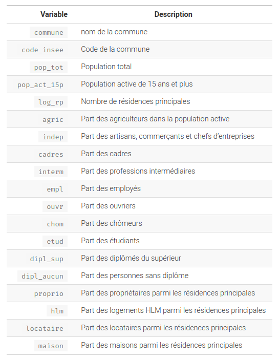

**Coefficient de corrélation**

Pour déterminer la relation entre deux variables numériques, calcul du coefficient de corrélation.  
Le coefficient de corrélation varie entre -1 et 1, il mesure la force et le sens de la relation entre deux variables.  
Un coefficient proche de -1 indique une relation négative (lorsque l’une des variables augmente l’autre diminue), et un coefficient proche de 1 indique une relation positive (les deux variables vont dans le même sens).

```r
cor(rp2012$cadres, rp2012$dipl_sup)
```

```
## [1] 0.9371629
```

Le coefficient indique qu’il y a une forte relation linéaire positive.

Test statistique correspondant avec la fonction *cor.test()*  
$H_0$ : le coefficient est égal à 0

```r
cor.test(rp2012$cadres, rp2012$dipl_sup)
```

```
##
##  Pearson's product-moment correlation
##
## data:  rp2012$cadres and rp2012$dipl_sup
## t = 193.1, df = 5168, p-value < 2.2e-16
## alternative hypothesis: true correlation is not equal to 0
## 95 percent confidence interval:
##  0.9337577 0.9403985
## sample estimates:
##       cor
## 0.9371629
```

Rejet de $H_0$, la corrélation est significativement différente de 0.

💻 **Pratique**

Analyser la relation entre les variables dipl_aucun (proportion de personnes sans diplômes) et proprio

# 7. Visualisation d’un jeu de données

dataset pour travailler : un sous-ensemble des données rp2012

```r
rp <- rp2012 |> filter(departement %in% c("Oise", "Rhône", "Hauts-de-Seine", "Lozère", "Bouches-du-Rhône"))
head(rp)
```

```
## # A tibble: 6 × 60
##   code_insee commune     code_region region code_departement departement pop_tot
##   <chr>      <chr>       <chr>       <chr>  <chr>            <chr>         <int>
## 1 13001      Aix-en-Pro… 93          Prove… 13               Bouches-du…  141148
## 2 13002      Allauch     93          Prove… 13               Bouches-du…   20690
## 3 13003      Alleins     93          Prove… 13               Bouches-du…    2428
## 4 13004      Arles       93          Prove… 13               Bouches-du…   52439
## 5 13005      Aubagne     93          Prove… 13               Bouches-du…   45243
## 6 13007      Auriol      93          Prove… 13               Bouches-du…   11621
## # ℹ 53 more variables: pop_cl <fct>, pop_0_14 <int>, pop_15_29 <int>,
## #   pop_18_24 <int>, pop_75p <int>, pop_femmes <int>, pop_act_15p <int>,
## #   pop_chom <int>, pop_agric <int>, pop_indep <int>, pop_cadres <int>,
## #   pop_interm <int>, pop_empl <int>, pop_ouvr <int>, pop_scol_18_24 <int>,
## #   pop_non_scol_15p <int>, pop_dipl_aucun <int>, pop_dipl_bepc <int>,
## #   pop_dipl_capbep <int>, pop_dipl_bac <int>, pop_dipl_bac2 <int>,
## #   pop_dipl_sup <int>, log_rp <int>, log_proprio <int>, log_loc <int>, …
```

**Fonctionnement général de ggplot2**

- initialisation de la fonction graphique avec `ggplot()`
- ajout des graphiques avec `geom_` (histogramme, nuage de points, boxplot, barres, courbes, …)
- personnalisation des graphiques avec des arguments dans les fonctions `geom_` et `aes()`
- la fonction `aes()` permet de mapper les variables du dataset aux éléments du graphique

## Une variable

### Histogramme

**`geom_histogram`**

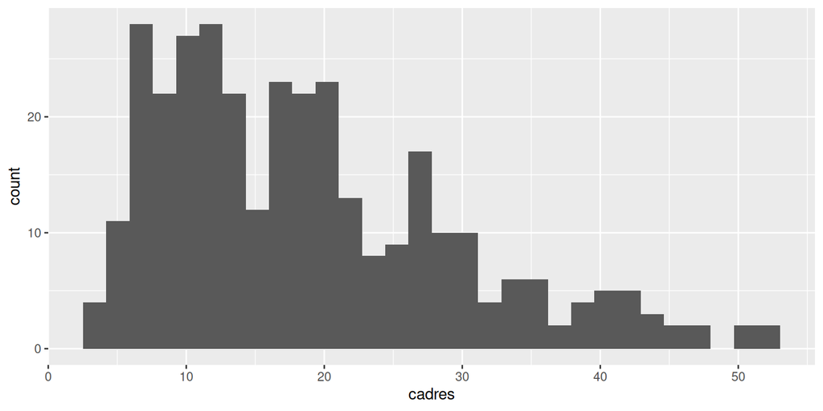

```r
ggplot(data=rp) +
  geom_histogram(aes(x=cadres))
```

Personnalisation des classes avec breaks

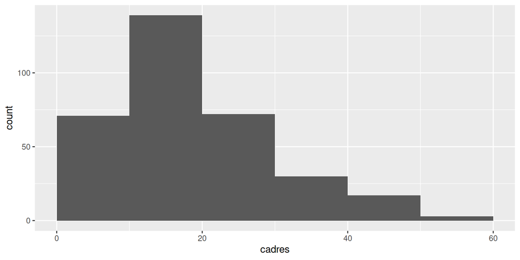

```r
ggplot(data=rp) +
  geom_histogram(aes(x=cadres), breaks=seq(0, 60, 10))
```

### Boîte à moustaches

**`geom_boxplot`**

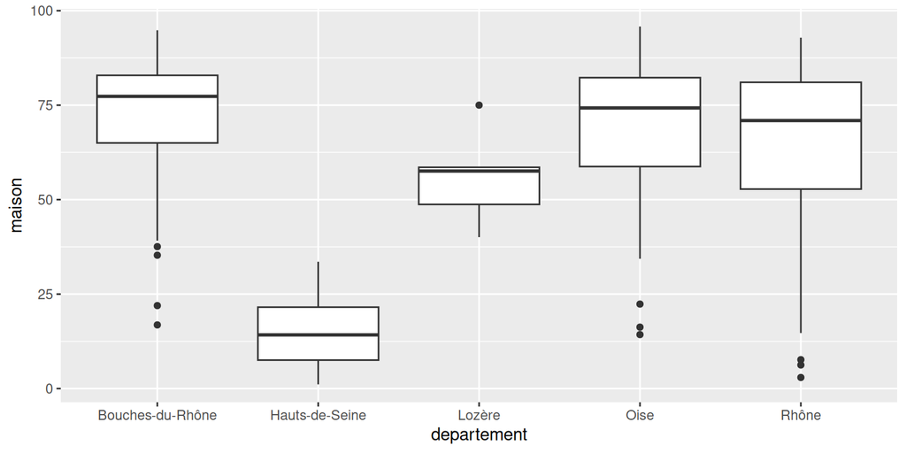

```r
ggplot(data=rp) +
  geom_boxplot(aes(x=departement, y=maison))
```

L’argument varwidth permet que la largeur de la box soit proportionnelle au nombre d’observations

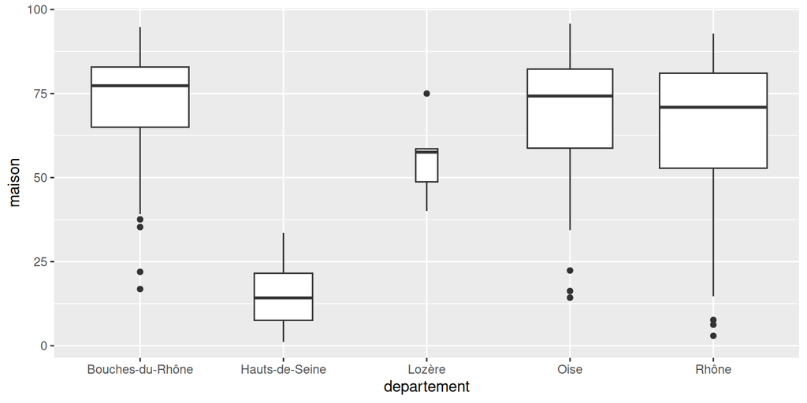

```r
ggplot(data=rp) +
  geom_boxplot(aes(x=departement, y=maison), varwidth=T)
```

### Barres

**`geom_bar`**

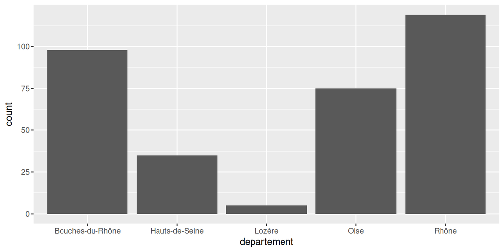

```r
ggplot(data=rp) +
  geom_bar(aes(x=departement))
```

**`geom_col`** pour un graphique en colonnes avec des valeurs personnalisées (ici le pourcentage)

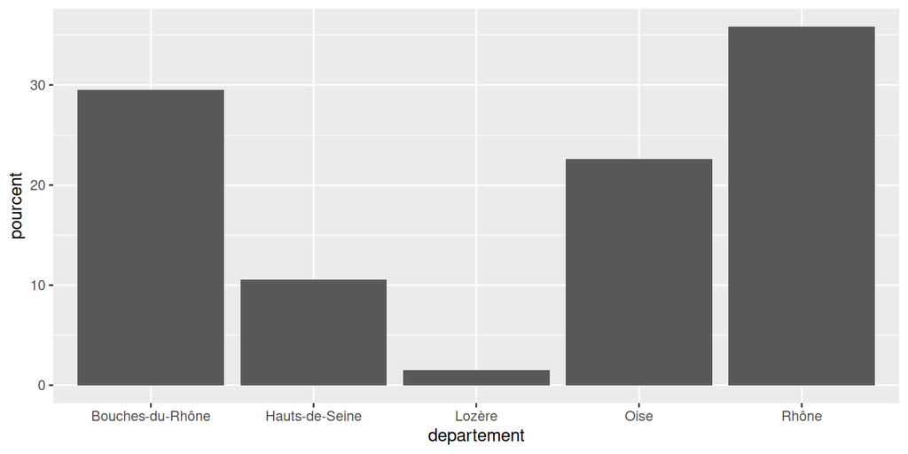

```r
rp |>
  group_by(departement) |>
  summarise(n=n()) |>
  mutate(pourcent=n/sum(n) * 100) |>
  ggplot() +
  geom_col(aes(x=departement, y=pourcent))
```

### Camembert

**`geom_col` avec coordonnées polaires**

ggplot2 ne propose pas de graphique camembert, mais on peut le faire avec coordonnées polaires

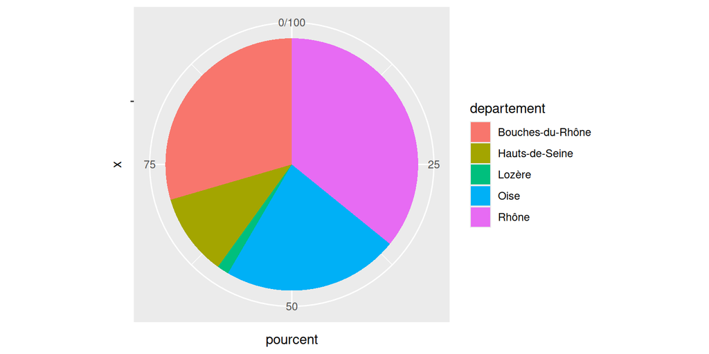

```r
rp |>
  group_by(departement) |>
  summarise(n=n()) |>
  mutate(pourcent=n/sum(n) * 100) |>
  ggplot() +
  geom_col(aes(x="", y=pourcent, fill=departement)) +
  coord_polar("y", start=0)
```

## Deux variables

### Nuage de points

**`geom_point`** avec 2 arguments dans `aes()`, la variable x et la variable y

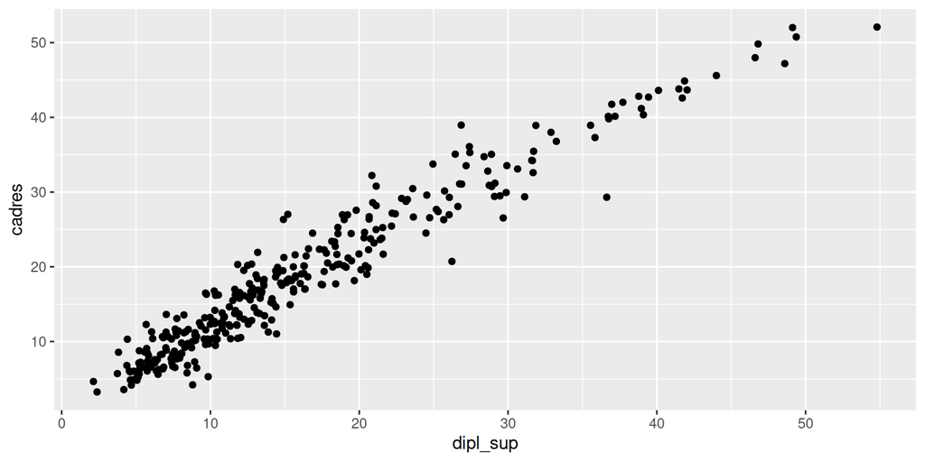

```r
ggplot(data=rp) +
  geom_point(aes(x=dipl_sup, y=cadres))
```

**Ajout d’une droite de régression avec `geom_smooth`** en plus de `geom_point`

💡 Si plusieurs `geom` utilisent les mêmes éléments dans `aes`, la fonction `aes()` peut être appelée dans `ggplot`

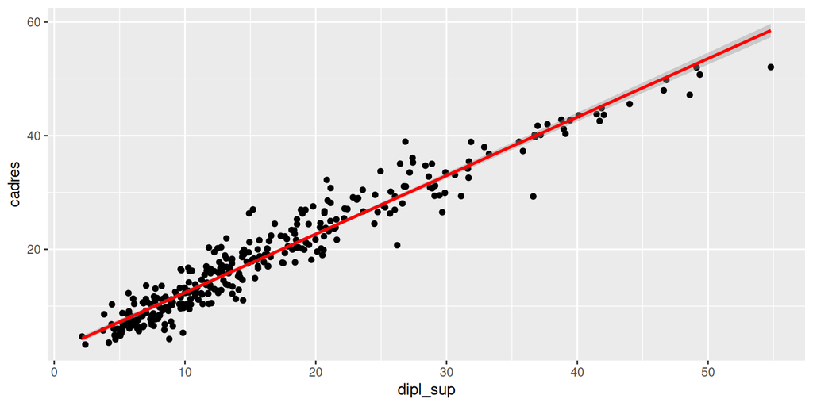

```r
ggplot(rp, aes(x=dipl_sup, y=cadres)) +
  geom_point() + geom_smooth(method ="lm", color="red")
```

### Courbes

chargement d’un jeu de données du package ggplot2 : economics

```r
data(package="ggplot2", "economics")
```

```r
head(economics)
```

```
## # A tibble: 6 × 6
##   date         pce    pop psavert uempmed unemploy
##   <date>     <dbl>  <dbl>   <dbl>   <dbl>    <dbl>
## 1 1967-07-01  507. 198712    12.6     4.5     2944
## 2 1967-08-01  510. 198911    12.6     4.7     2945
## 3 1967-09-01  516. 199113    11.9     4.6     2958
## 4 1967-10-01  512. 199311    12.9     4.9     3143
## 5 1967-11-01  517. 199498    12.8     4.7     3066
## 6 1967-12-01  525. 199657    11.8     4.8     3018
```

**`geom_line`**

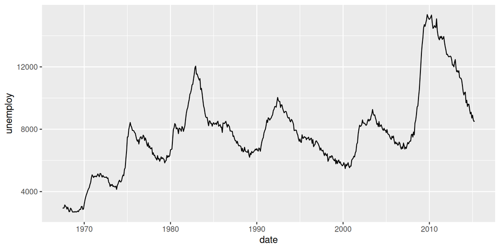

```r
chom <- economics |> select(date, unemploy)
ggplot(chom) +
  geom_line(aes(x=date, y=unemploy))
```

💡 Pour ajouter plusieurs courbes dans le graphique, plusieurs appels à `geom_line` (avec “+” entre chaque)

## Trois ou quatre variables

**Le mappage**

- Associer un des attributs du graphique (couleur, taille) à une variable
- Permet de visualiser une troisième dimension (voire une quatrième)
- Le mappage se fait dans l’appel de la fonction `aes()`

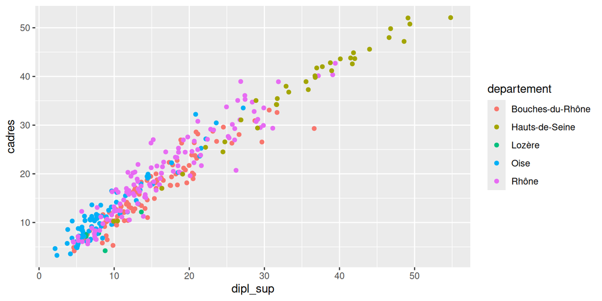

```r
ggplot(rp) +
  geom_point(aes(x = dipl_sup, y = cadres, color = departement))
```

Ajout d’une 4ème dimension avec la taille des points, ici la population totale de la commune

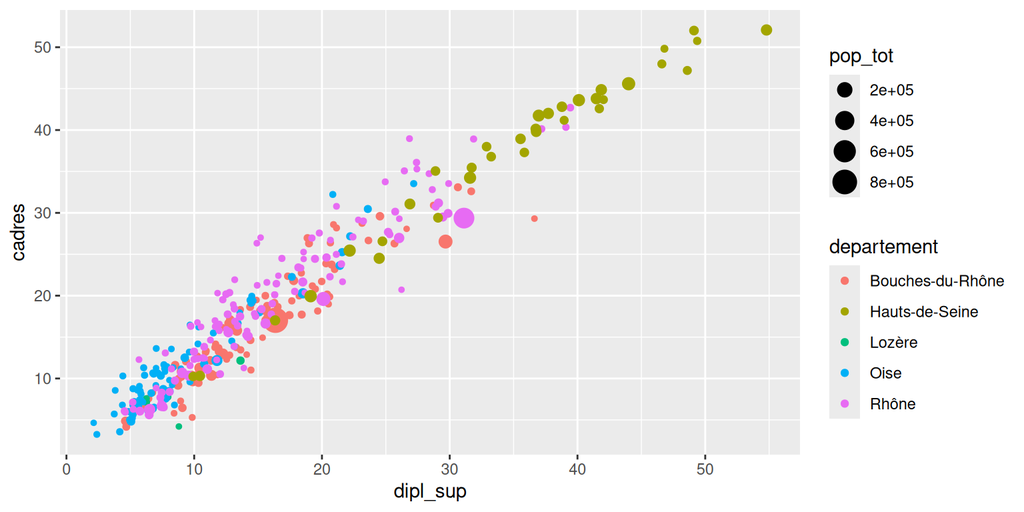

```r
ggplot(rp) +
  geom_point(aes(x=dipl_sup, y=cadres, color=departement, size=pop_tot))
```

## Le faceting

Décomposer un graphique en plusieurs, selon les modalités d’une ou plusieurs variables catégorielles

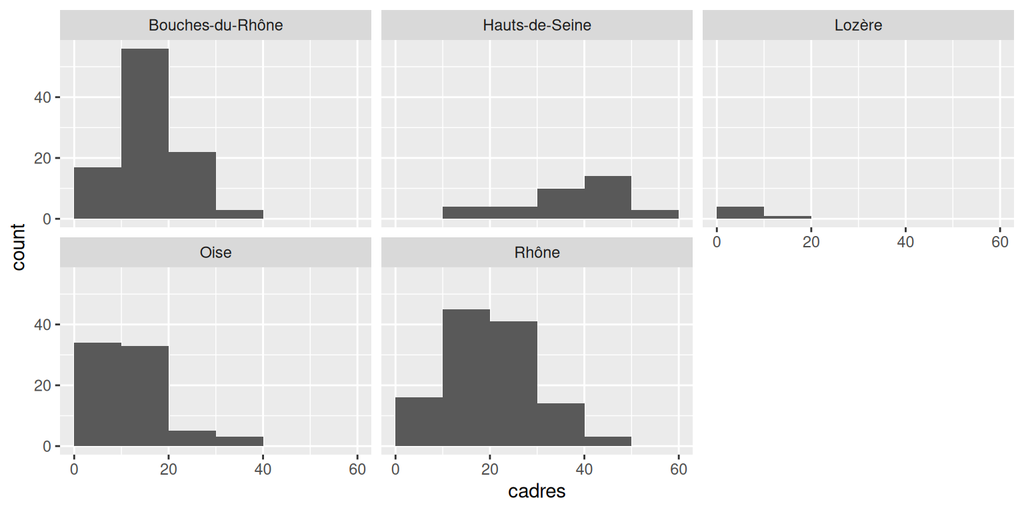

```r
ggplot(rp) +
  geom_histogram(aes(x=cadres), breaks=seq(0, 60, 10)) +
  facet_wrap(vars(departement))
```

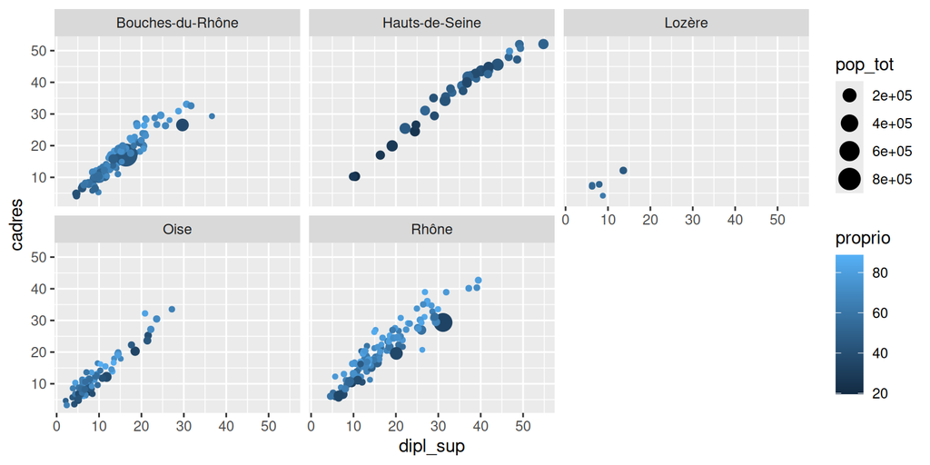

```r
ggplot(rp) +
  geom_point(aes(x=dipl_sup, y=cadres, color=proprio, size=pop_tot)) +
  facet_wrap(vars(departement))
```

## Personnalisation des graphiques

- `theme` pour l’aspect général
- `labs` pour les titres des axes et du graphique
- `scale_*` pour la personnalisation des échelles

`theme` pour la personnalisation

Existe : `theme_gray` (défault), `theme_minimal`, `theme_light`, `theme_dark`, `theme_bw`, `theme_classic`, `theme_void`

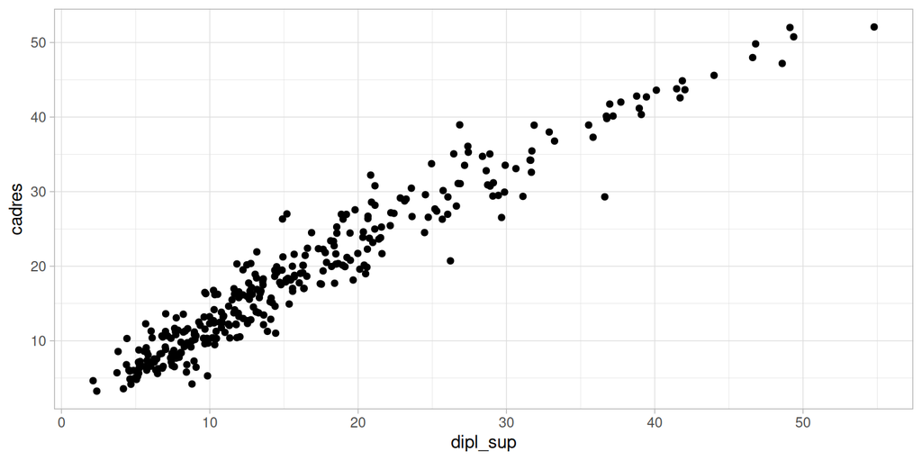

```r
ggplot(rp) +
  geom_point(aes(x=dipl_sup, y=cadres)) +
  theme_light()
```

`labs` pour les titres

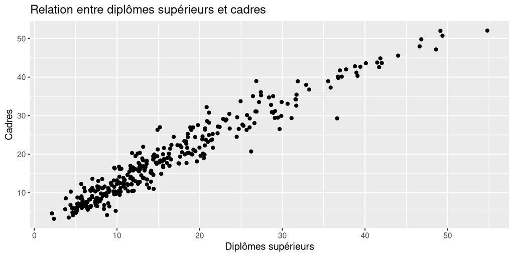

```r
ggplot(rp) +
  geom_point(aes(x=dipl_sup, y=cadres)) +
  labs(title="Relation entre diplômes supérieurs et cadres", x="Diplômes supérieurs", y="Cadres")
```

`scale_x_continuous` et `scale_y_continuous` pour les axes x et y de données quantitatives

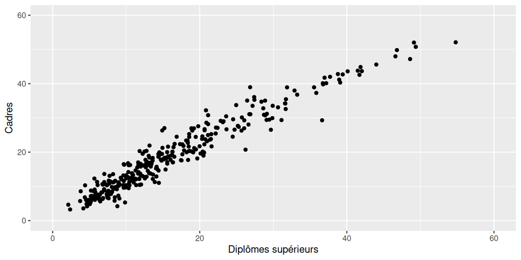

```r
ggplot(data=rp) +
  geom_point(aes(x=dipl_sup, y=cadres)) +
  scale_x_continuous("Diplômes supérieurs", limits=c(0, 60)) +
  scale_y_continuous("Cadres", limits=c(0, 60))
```

`scale_x_discrete` et `scale_y_discrete` pour les variables catégorielles

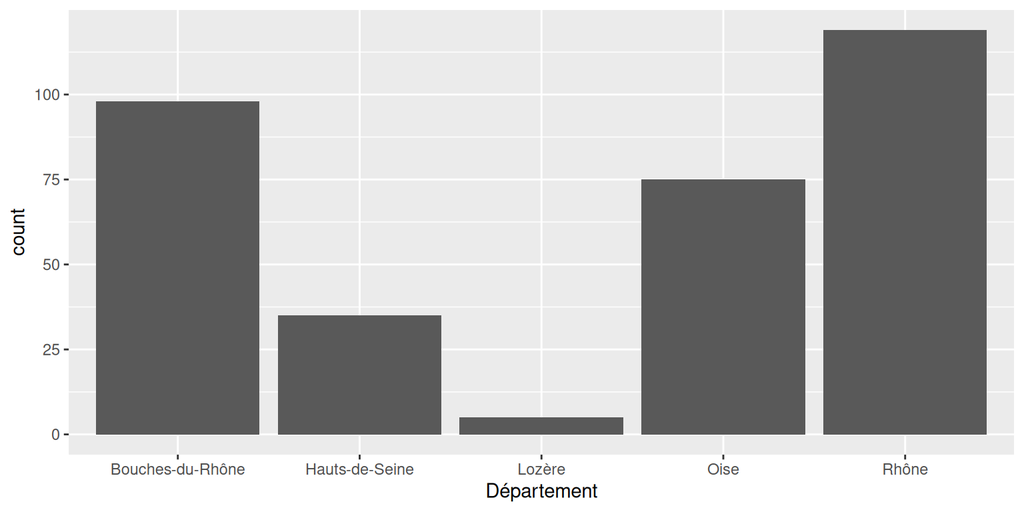

```r
ggplot(rp) +
  geom_bar(aes(x = departement)) +
  scale_x_discrete("Département")
```

💡 le package `esquisse` propose un Addins pour faire les graphiques `Addins/ggplot2 builder`

💻 **Pratique**

Avec le dataset rp2012

1. un nuage de points x=dipl_aucun et y=ouvr, avec titre des axes, et points en bleu
2. même graphique que précédemment mais avec un mappage de couleur selon la région
3. boxplot: distribution de la variable proprio par rapport à la taille de departement (pop_cl)
4. graphique en barres avec le nombre total de propriétaires par région
5. nuage de points avec en x=dipl_sup et y=cadres avec un graphique par région (facet_wrap)

# Sources

- un ouvrage complet sur l’analyse de données avec R [ici](https://larmarange.github.io/analyse-R/analyse-R.pdf)
- le cours de Julien Barnier (package `questionr`) accessible en ligne [ici](https://juba.github.io/tidyverse/index.html)
- le site https://www.tidyverse.org/
- le site [R for data science](https://r4ds.had.co.nz/index.html)
- le site de ggplot2 http://ggplot2.tidyverse.org/reference/
- des exemples de graphiques avec ggplot2 : http://www.cookbook-r.com/Graphs/